# Hábitos de sueño, consumo de bebidas energéticas y bienestar estudiantil

Avance 1 — Probabilidad Empírica · Avance 2 — Variables Aleatorias · Ciclo 2026-I

Authors

Piero Max Ortiz Villafuerte (Líder)

Joel Modesto Cayllahua Hilario

Salvador Donayre Epifania

Sebastian Ernesto Chahuara Galdos

Marisol Yaranga Delgado

# AVANCE 1 — Probabilidad Empírica

# 1 Verificación de observaciones limpias

El análisis de probabilidad se realiza con **los datos de toda la sección**. El filtro por grupo únicamente se aplica para verificar que el Grupo 8 alcanzó el mínimo de 150 observaciones limpias requerido.

```r
cat("Observaciones limpias — Grupo 8:         ", n_grupo8, "\n")
```

```
Observaciones limpias — Grupo 8:          153
```

```r
cat("Observaciones limpias — Sección completa:", n_seccion, "\n")
```

```
Observaciones limpias — Sección completa: 1192
```

El Grupo 8 cuenta con **153 observaciones limpias**. El análisis probabilístico se realiza sobre la muestra efectiva de toda la sección: **n = 1192**.

# 2 Variable 1: Frecuencia de consumo de bebidas energéticas

**Tipo:** Cuantitativa discreta

**Distribución de frecuencias observadas:**

| Días/semana | Frecuencia | P(Eᵢ) |
| --- | --- | --- |
| 0 | 621 | 0.5210 |
| 1 | 178 | 0.1493 |
| 2 | 151 | 0.1267 |
| 3 | 91 | 0.0763 |
| 4 | 63 | 0.0529 |
| 5 | 57 | 0.0478 |
| 6 | 14 | 0.0117 |
| 7 | 17 | 0.0143 |

## 2.1 Experimento aleatorio

$EA_1$: Seleccionar una persona al azar del estudio (la unidad muestral) y observar la cantidad de días a la semana en que consume bebidas energéticas.

## 2.2 Espacio muestral

$$\Omega_{EA_1} = \{0,\ 1,\ 2,\ 3,\ 4,\ 5,\ 6,\ 7\}$$

## 2.3 Eventos atómicos

- $E_1$: Seleccionar una persona al azar del estudio cuya frecuencia de consumo de bebidas energéticas es **0 días por semana**
- $E_2$: Seleccionar una persona al azar del estudio cuya frecuencia de consumo de bebidas energéticas es **1 día por semana**
- $E_3$: Seleccionar una persona al azar del estudio cuya frecuencia de consumo de bebidas energéticas es **2 días por semana**
- $E_4$: Seleccionar una persona al azar del estudio cuya frecuencia de consumo de bebidas energéticas es **3 días por semana**
- $E_5$: Seleccionar una persona al azar del estudio cuya frecuencia de consumo de bebidas energéticas es **4 días por semana**
- $E_6$: Seleccionar una persona al azar del estudio cuya frecuencia de consumo de bebidas energéticas es **5 días por semana**
- $E_7$: Seleccionar una persona al azar del estudio cuya frecuencia de consumo de bebidas energéticas es **6 días por semana**
- $E_8$: Seleccionar una persona al azar del estudio cuya frecuencia de consumo de bebidas energéticas es **7 días por semana**

## 2.4 Probabilidades empíricas

```r
n_v1 <- sum(!is.na(DF_seccion$FrecBebida))

P_E1 <- sum(DF_seccion$FrecBebida == 0, na.rm = TRUE) / n_v1
P_E2 <- sum(DF_seccion$FrecBebida == 1, na.rm = TRUE) / n_v1
P_E3 <- sum(DF_seccion$FrecBebida == 2, na.rm = TRUE) / n_v1
P_E4 <- sum(DF_seccion$FrecBebida == 3, na.rm = TRUE) / n_v1
P_E5 <- sum(DF_seccion$FrecBebida == 4, na.rm = TRUE) / n_v1
P_E6 <- sum(DF_seccion$FrecBebida == 5, na.rm = TRUE) / n_v1
P_E7 <- sum(DF_seccion$FrecBebida == 6, na.rm = TRUE) / n_v1
P_E8 <- sum(DF_seccion$FrecBebida == 7, na.rm = TRUE) / n_v1

cat("P(E1) — 0 días:", round(P_E1, 4), "\n")
```

```
P(E1) — 0 días: 0.521
```

```r
cat("P(E2) — 1 día: ", round(P_E2, 4), "\n")
```

```
P(E2) — 1 día:  0.1493
```

```r
cat("P(E3) — 2 días:", round(P_E3, 4), "\n")
```

```
P(E3) — 2 días: 0.1267
```

```r
cat("P(E4) — 3 días:", round(P_E4, 4), "\n")
```

```
P(E4) — 3 días: 0.0763
```

```r
cat("P(E5) — 4 días:", round(P_E5, 4), "\n")
```

```
P(E5) — 4 días: 0.0529
```

```r
cat("P(E6) — 5 días:", round(P_E6, 4), "\n")
```

```
P(E6) — 5 días: 0.0478
```

```r
cat("P(E7) — 6 días:", round(P_E7, 4), "\n")
```

```
P(E7) — 6 días: 0.0117
```

```r
cat("P(E8) — 7 días:", round(P_E8, 4), "\n")
```

```
P(E8) — 7 días: 0.0143
```

## 2.5 Comprobación

```r
P_E1 + P_E2 + P_E3 + P_E4 + P_E5 + P_E6 + P_E7 + P_E8
```

```
[1] 1
```

## 2.6 Visualización

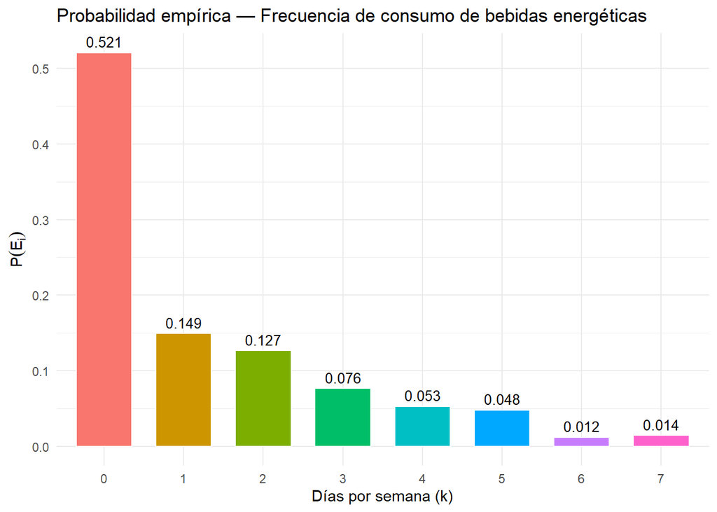

# 3 Variable 2: Calidad de sueño autopercibida

**Tipo:** Cualitativa ordinal

**Distribución de frecuencias observadas:**

| Categoría | Frecuencia | P(Eᵢ) |
| --- | --- | --- |
| Muy mala | 70 | 0.0587 |
| Mala | 247 | 0.2072 |
| Regular | 577 | 0.4841 |
| Buena | 239 | 0.2005 |
| Muy buena | 59 | 0.0495 |

## 3.1 Experimento aleatorio

$EA_2$: Seleccionar una persona al azar del estudio (la unidad muestral) y observar su calificación subjetiva de la calidad de su sueño durante el ciclo académico 2026-I.

## 3.2 Espacio muestral

$$\Omega_{EA_2} = \{\text{Muy mala},\ \text{Mala},\ \text{Regular},\ \text{Buena},\ \text{Muy buena}\}$$

## 3.3 Eventos atómicos

- $E_1$: Seleccionar una persona al azar del estudio cuya calidad de sueño autopercibida es **Muy mala**
- $E_2$: Seleccionar una persona al azar del estudio cuya calidad de sueño autopercibida es **Mala**
- $E_3$: Seleccionar una persona al azar del estudio cuya calidad de sueño autopercibida es **Regular**
- $E_4$: Seleccionar una persona al azar del estudio cuya calidad de sueño autopercibida es **Buena**
- $E_5$: Seleccionar una persona al azar del estudio cuya calidad de sueño autopercibida es **Muy buena**

## 3.4 Probabilidades empíricas

```r
cs <- as.character(DF_seccion$CalidadSuenio)
n_v2 <- sum(!is.na(cs))

P_E1_cs <- sum(cs == "Muy mala",  na.rm = TRUE) / n_v2
P_E2_cs <- sum(cs == "Mala",      na.rm = TRUE) / n_v2
P_E3_cs <- sum(cs == "Regular",   na.rm = TRUE) / n_v2
P_E4_cs <- sum(cs == "Buena",     na.rm = TRUE) / n_v2
P_E5_cs <- sum(cs == "Muy buena", na.rm = TRUE) / n_v2

cat("P(E1) — Muy mala: ", round(P_E1_cs, 4), "\n")
```

```
P(E1) — Muy mala:  0.0587
```

```r
cat("P(E2) — Mala:     ", round(P_E2_cs, 4), "\n")
```

```
P(E2) — Mala:      0.2072
```

```r
cat("P(E3) — Regular:  ", round(P_E3_cs, 4), "\n")
```

```
P(E3) — Regular:   0.4841
```

```r
cat("P(E4) — Buena:    ", round(P_E4_cs, 4), "\n")
```

```
P(E4) — Buena:     0.2005
```

```r
cat("P(E5) — Muy buena:", round(P_E5_cs, 4), "\n")
```

```
P(E5) — Muy buena: 0.0495
```

## 3.5 Comprobación

```r
P_E1_cs + P_E2_cs + P_E3_cs + P_E4_cs + P_E5_cs
```

```
[1] 1
```

## 3.6 Visualización

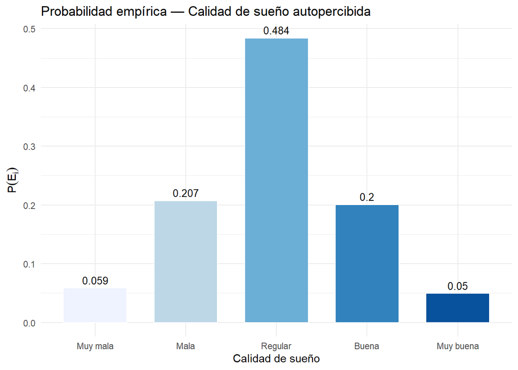

## 3.7 Interpretación

La distribución de probabilidades muestra que la percepción de calidad de sueño **Regular** es la más frecuente entre los estudiantes, con una probabilidad de **P(E₃) = 0.484**, concentrando casi la mitad de las observaciones. Le siguen las categorías **Mala** (P(E₂) = 0.207) y **Buena** (P(E₄) = 0.201), mientras que los extremos son notablemente menos probables: **Muy mala** (P(E₁) = 0.059) y **Muy buena** (P(E₅) = 0.049). En conjunto, la probabilidad de que un estudiante seleccionado al azar perciba su sueño como negativo (Muy mala o Mala) asciende a aproximadamente **0.266**, lo que indica que más de una cuarta parte de los estudiantes reporta una calidad de descanso deficiente durante el ciclo académico 2026-I.

# 4 Probabilidad condicional

## 4.1 1. Definición de eventos

Se definen dos eventos, uno simple y otro compuesto respectivamente, uno por cada variable de estudio:

- $E_1$: Seleccionar un estudiante al azar de la sección que **no consume bebidas energéticas** (FrecBebida = 0)
- $E_2$: Seleccionar un estudiante al azar de la sección cuya **calidad de sueño autopercibida es Regular, Mala o Muy mala**

```r
DF_cond <- DF_seccion %>%
  filter(!is.na(FrecBebida), !is.na(CalidadSuenio)) %>%
  mutate(
    E1 = ifelse(FrecBebida == 0, "No consume", "Consume"),
    E2 = ifelse(as.character(CalidadSuenio) %in% c("Muy mala", "Mala", "Regular"),
                "Sueño regular o peor", "Sueño bueno o muy bueno")
  )

# Tabla de contingencia (frecuencias absolutas)
tabla_cond <- table(E1 = DF_cond$E1, E2 = DF_cond$E2)

tabla_df <- as.data.frame.matrix(tabla_cond)
tabla_df$Total <- rowSums(tabla_df)
tabla_df <- rbind(tabla_df, Total = colSums(tabla_df))
tabla_df
```

```
           Sueño bueno o muy bueno Sueño regular o peor Total
Consume                        146                  425   571
No consume                     152                  469   621
Total                          298                  894  1192
```

```r
frec_table <- round(prop.table(tabla_cond) * 100, 2)
frec_df <- as.data.frame.matrix(frec_table)
frec_df$Total <- rowSums(frec_df)
frec_df <- rbind(frec_df, Total = colSums(frec_df))
frec_df
```

```
           Sueño bueno o muy bueno Sueño regular o peor Total
Consume                      12.25                35.65  47.9
No consume                   12.75                39.35  52.1
Total                        25.00                75.00 100.0
```

## 4.2 2. Prueba de independencia

```r
n_cond <- nrow(DF_cond)
no_consume    <- sum(DF_cond$E1 == "No consume")
suenio_reg_peor <- sum(DF_cond$E2 == "Sueño regular o peor")

P_E1 <- no_consume / n_cond
P_E2 <- suenio_reg_peor / n_cond

P_E1_intersect_E2 <- sum(DF_cond$E1 == "No consume" &
                           DF_cond$E2 == "Sueño regular o peor") / n_cond

P_E1_union_E2 <- sum(DF_cond$E1 == "No consume" |
                       DF_cond$E2 == "Sueño regular o peor") / n_cond

cat("P(E1)                =", round(P_E1, 4), "\n")
```

```
P(E1)                = 0.521
```

```r
cat("P(E2)                =", round(P_E2, 4), "\n")
```

```
P(E2)                = 0.75
```

```r
cat("P(E1 intersect E2)   =", round(P_E1_intersect_E2, 4), "\n")
```

```
P(E1 intersect E2)   = 0.3935
```

```r
cat("P(E1) * P(E2)        =", round(P_E1 * P_E2, 4), "\n")
```

```
P(E1) * P(E2)        = 0.3907
```

```r
if(round(P_E1_intersect_E2, 4) == round(P_E1 * P_E2, 4)) {
  cat("Los eventos son INDEPENDIENTES")
} else {
  cat("Los eventos son DEPENDIENTES")
}
```

```
Los eventos son DEPENDIENTES
```

## 4.3 3. Propiedades

```r
P_E1_E2  <- P_E1_intersect_E2 / P_E2
P_E2_E1  <- P_E1_intersect_E2 / P_E1
P_E1_E1E2 <- P_E1 * P_E2_E1
P_E2c    <- 1 - P_E2

P_E1_E2c <- sum(DF_cond$E1 == "No consume" &
                DF_cond$E2 == "Sueño bueno o muy bueno") /
             sum(DF_cond$E2 == "Sueño bueno o muy bueno")

P_E2_E1c <- sum(DF_cond$E1 == "Consume" &
                DF_cond$E2 == "Sueño regular o peor") /
             sum(DF_cond$E1 == "Consume")

cat("P(E1|E2)                =", round(P_E1_E2,   4), "\n")
```

```
P(E1|E2)                = 0.5246
```

```r
cat("P(E2|E1)                =", round(P_E2_E1,   4), "\n")
```

```
P(E2|E1)                = 0.7552
```

```r
cat("P(E1 union E2)          =", round(P_E1_union_E2, 4), "\n")
```

```
P(E1 union E2)          = 0.8775
```

```r
cat("P(E1) * P(E2)           =", round(P_E1 * P_E2, 4), "\n")
```

```
P(E1) * P(E2)           = 0.3907
```

```r
cat("P(E1) * P(E2|E1)        =", round(P_E1_E1E2, 4), "\n")
```

```
P(E1) * P(E2|E1)        = 0.3935
```

```r
cat("P(E2 complemento)       =", round(P_E2c,     4), "\n")
```

```
P(E2 complemento)       = 0.25
```

```r
cat("P(E1|E2 complemento)    =", round(P_E1_E2c,  4), "\n")
```

```
P(E1|E2 complemento)    = 0.5101
```

```r
cat("P(E2|E1 complemento)    =", round(P_E2_E1c,  4), "\n")
```

```
P(E2|E1 complemento)    = 0.7443
```

```r
if (round(P_E1_E1E2, 4) == round(P_E1_intersect_E2, 4)) {
  cat("Se cumple la propiedad: P(E1 intersect E2) = P(E1) * P(E2|E1)")
}
```

```
Se cumple la propiedad: P(E1 intersect E2) = P(E1) * P(E2|E1)
```

## 4.4 4. Teorema de Bayes

Verificación de $P(E_2 | E_1)$ aplicando el teorema de Bayes:

$$P(E_2 | E_1) = \frac{P(E_1 | E_2) \cdot P(E_2)}{P(E_1 | E_2) \cdot P(E_2) + P(E_1 | E_2^c) \cdot P(E_2^c)}$$

```r
Bayes <- (P_E1_E2 * P_E2) / ((P_E1_E2 * P_E2) + (P_E1_E2c * P_E2c))

cat("T. Bayes  =", round(Bayes, 4), "\n")
```

```
T. Bayes  = 0.7552
```

```r
if (round(Bayes, 4) == round(P_E2_E1, 4)) {
  cat("Se cumple el Teorema de Bayes")
}
```

```
Se cumple el Teorema de Bayes
```

Ambos métodos coinciden, lo que valida el cálculo.

# AVANCE 2 — Variables Aleatorias

# 5 Variable Discreta 1: Consumo de bebidas energéticas

**Variable de estudio:** Frecuencia de consumo de bebidas energéticas (`FrecBebida`) — Cuantitativa discreta (días por semana, 0–7)

## 5.1 Paso 1: Construcción del caso

A partir de los datos de la sección, se estima la probabilidad de que un estudiante seleccionado al azar **consuma bebidas energéticas al menos un día a la semana**. Con ese parámetro se plantea el siguiente caso:

> Se desea saber cuántos estudiantes deben ser seleccionados al azar, uno a uno, hasta encontrar al **primer estudiante que consume bebidas energéticas**.

## 5.2 Paso 2: Variable aleatoria discreta y distribución teórica

$$X: \text{Número de estudiantes seleccionados hasta encontrar el primero que consume bebidas energéticas}$$

$$X \sim \text{Geom}(p)$$

Donde:

- **Éxito:** seleccionar un estudiante que consume bebidas energéticas (FrecBebida > 0)
- **p** = P(Éxito) = P(estudiante consume bebidas energéticas) estimado desde los datos

```r
cat("n con dato válido de FrecBebida:", n_fb, "\n")
```

```
n con dato válido de FrecBebida: 1192
```

```r
cat("p = P(consume bebidas energéticas):", round(p_consume, 4), "\n")
```

```
p = P(consume bebidas energéticas): 0.479
```

## 5.3 Paso 3: Descripción de la distribución teórica

- $P(X = 1)$: probabilidad de que el **primer** estudiante seleccionado ya consuma bebidas energéticas
- $P(X = 2)$: probabilidad de que el **segundo** sea el primero en consumirlas (el primero no consumía)
- $P(X = k)$: probabilidad de que sean necesarios exactamente $k$ intentos para encontrar el primer consumidor
- El soporte de $X$ es $\{1, 2, 3, \ldots\}$

## 5.4 Paso 4: Propiedades de la distribución

```r
E_X1  <- 1 / p_consume
V_X1  <- (1 - p_consume) / p_consume^2
SD_X1 <- sqrt(V_X1)

cat("E(X)  = 1/p        =", round(E_X1,  4), "\n")
```

```
E(X)  = 1/p        = 2.0876
```

```r
cat("V(X)  = (1-p)/p²   =", round(V_X1,  4), "\n")
```

```
V(X)  = (1-p)/p²   = 2.2704
```

```r
cat("SD(X) = sqrt(V(X)) =", round(SD_X1, 4), "\n")
```

```
SD(X) = sqrt(V(X)) = 1.5068
```

En promedio, se necesitan **2.1 estudiantes** para encontrar el primero que consume bebidas energéticas.

## 5.5 Paso 5: Respuesta al caso

```r
k_caso1 <- 3
P_X_igual_k <- dgeom(k_caso1 - 1, prob = p_consume)

cat("P(X =", k_caso1, ") =", round(P_X_igual_k, 6), "\n")
```

```
P(X = 3 ) = 0.130014
```

```r
cat("Interpretación: hay una probabilidad de", round(P_X_igual_k * 100, 2),
    "% de que el tercer estudiante seleccionado sea el primero en consumir bebidas energéticas.\n")
```

```
Interpretación: hay una probabilidad de 13 % de que el tercer estudiante seleccionado sea el primero en consumir bebidas energéticas.
```

## 5.6 Paso 6: Distribución acumulada

```r
limite_acum1 <- 5
P_X_leq <- pgeom(limite_acum1 - 1, prob = p_consume)

cat("P(X <=", limite_acum1, ") =", round(P_X_leq, 4), "\n")
```

```
P(X <= 5 ) = 0.9616
```

```r
cat("Interpretación: hay una probabilidad de", round(P_X_leq * 100, 2),
    "% de encontrar al primer consumidor de bebidas energéticas dentro de los primeros",
    limite_acum1, "estudiantes seleccionados.\n")
```

```
Interpretación: hay una probabilidad de 96.16 % de encontrar al primer consumidor de bebidas energéticas dentro de los primeros 5 estudiantes seleccionados.
```

### 5.6.1 Visualización de la distribución

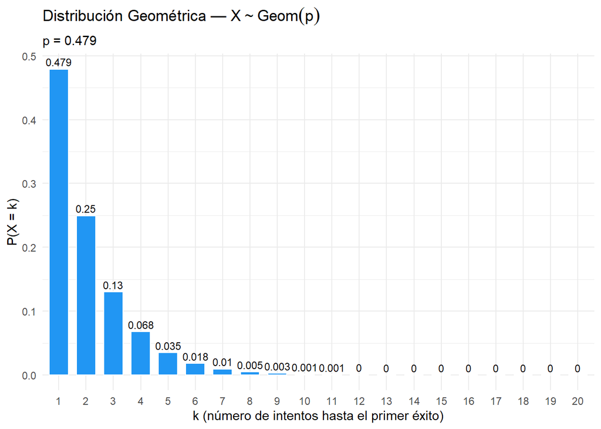

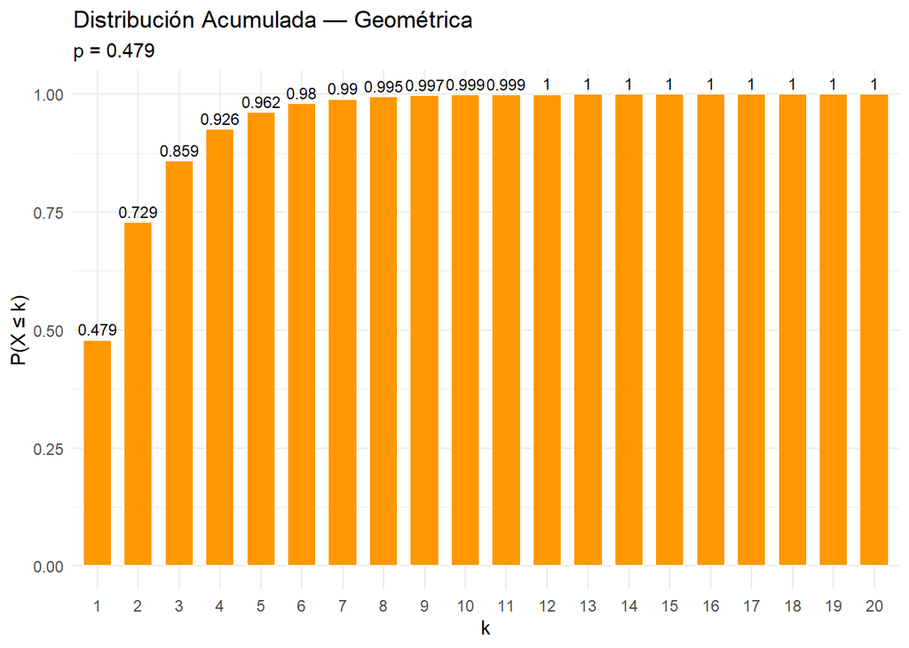

### 5.6.2 Interpretación

De los 1192 estudiantes con datos válidos, el **47.9%** consume bebidas energéticas al menos un día a la semana, por lo que $p = 0.479$.

Usando $X \sim \text{Geom}(0.479)$:

- $E(X) = 2.09$: en promedio se necesitan seleccionar **2 estudiantes** para encontrar al primero que consuma bebidas energéticas.
- $SD(X) = 1.51$: la variabilidad es baja, lo que significa que casi siempre el primer consumidor aparece en los primeros intentos.
- $P(X = 3) = 0.13$: hay un **13% de probabilidad** de que el tercer estudiante seleccionado sea el primero en consumir bebidas energéticas.
- $P(X \leq 5) = 0.9616$: hay un **96.16% de probabilidad** de encontrar al primer consumidor dentro de los primeros 5 estudiantes seleccionados.

# 6 Variable Discreta 2: Calidad de sueño deficiente

**Variable de estudio:** Calidad de sueño autopercibida (`CalidadSuenio`) — Cualitativa ordinal (Muy mala, Mala, Regular, Buena, Muy buena)

## 6.1 Paso 1: Construcción del caso

A partir de los datos de la sección, se estima la probabilidad de que un estudiante perciba su calidad de sueño como **Mala o Muy mala**. Con ese parámetro se plantea el siguiente caso:

> En un grupo de **10 estudiantes** seleccionados al azar de la sección, se desea saber cuántos reportan una calidad de sueño deficiente (Mala o Muy mala).

## 6.2 Paso 2: Variable aleatoria discreta y distribución teórica

$$Y: \text{Número de estudiantes con calidad de sueño deficiente en un grupo de 10}$$

$$Y \sim \text{Binomial}(n = 10,\ p)$$

Donde:

- **Éxito:** seleccionar un estudiante cuya calidad de sueño es Mala o Muy mala
- **n = 10:** tamaño del grupo
- **p** = P(Éxito) = P(calidad de sueño Mala o Muy mala) estimado desde los datos

```r
cat("n con dato válido de CalidadSuenio:", n_cs, "\n")
```

```
n con dato válido de CalidadSuenio: 1192
```

```r
cat("p = P(calidad de sueño Mala o Muy mala):", round(p_mal_suenio, 4), "\n")
```

```
p = P(calidad de sueño Mala o Muy mala): 0.2659
```

## 6.3 Paso 3: Descripción de la distribución teórica

- $P(Y = 0)$: probabilidad de que **ninguno** de los 10 tenga calidad de sueño deficiente
- $P(Y = 1)$: probabilidad de que **exactamente 1** de los 10 tenga calidad de sueño deficiente
- $P(Y = k)$: probabilidad de que exactamente $k$ de los 10 estudiantes tengan calidad de sueño deficiente
- El soporte de $Y$ es $\{0, 1, 2, \ldots, 10\}$

## 6.4 Paso 4: Propiedades de la distribución

```r
n_binom <- 10
E_Y  <- n_binom * p_mal_suenio
V_Y  <- n_binom * p_mal_suenio * (1 - p_mal_suenio)
SD_Y <- sqrt(V_Y)

cat("E(Y)  = n·p        =", round(E_Y,  4), "\n")
```

```
E(Y)  = n·p        = 2.6594
```

```r
cat("V(Y)  = n·p·(1-p)  =", round(V_Y,  4), "\n")
```

```
V(Y)  = n·p·(1-p)  = 1.9522
```

```r
cat("SD(Y) = sqrt(V(Y)) =", round(SD_Y, 4), "\n")
```

```
SD(Y) = sqrt(V(Y)) = 1.3972
```

En promedio, **2.66 de cada 10 estudiantes** seleccionados al azar reportarían una calidad de sueño deficiente.

## 6.5 Paso 5: Respuesta al caso

```r
k_caso2 <- 2
P_Y_igual_k <- dbinom(k_caso2, size = n_binom, prob = p_mal_suenio)

cat("P(Y =", k_caso2, ") =", round(P_Y_igual_k, 6), "\n")
```

```
P(Y = 2 ) = 0.268308
```

```r
cat("Interpretación: hay una probabilidad de", round(P_Y_igual_k * 100, 2),
    "% de que exactamente", k_caso2, "de los 10 estudiantes reporten calidad de sueño deficiente.\n")
```

```
Interpretación: hay una probabilidad de 26.83 % de que exactamente 2 de los 10 estudiantes reporten calidad de sueño deficiente.
```

## 6.6 Paso 6: Distribución acumulada

```r
limite_acum2 <- 3
P_Y_leq <- pbinom(limite_acum2, size = n_binom, prob = p_mal_suenio)

cat("P(Y <=", limite_acum2, ") =", round(P_Y_leq, 4), "\n")
```

```
P(Y <= 3 ) = 0.7375
```

```r
cat("Interpretación: hay una probabilidad de", round(P_Y_leq * 100, 2),
    "% de que a lo mucho", limite_acum2, "de los 10 estudiantes reporten calidad de sueño Mala o Muy mala.\n")
```

```
Interpretación: hay una probabilidad de 73.75 % de que a lo mucho 3 de los 10 estudiantes reporten calidad de sueño Mala o Muy mala.
```

### 6.6.1 Visualización de la distribución

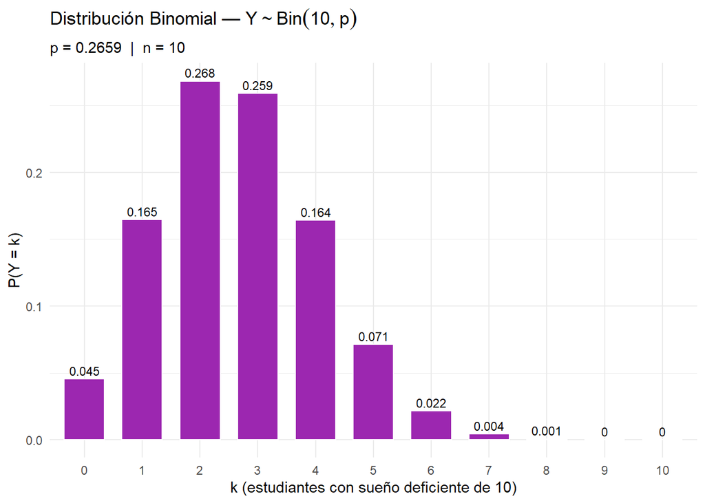

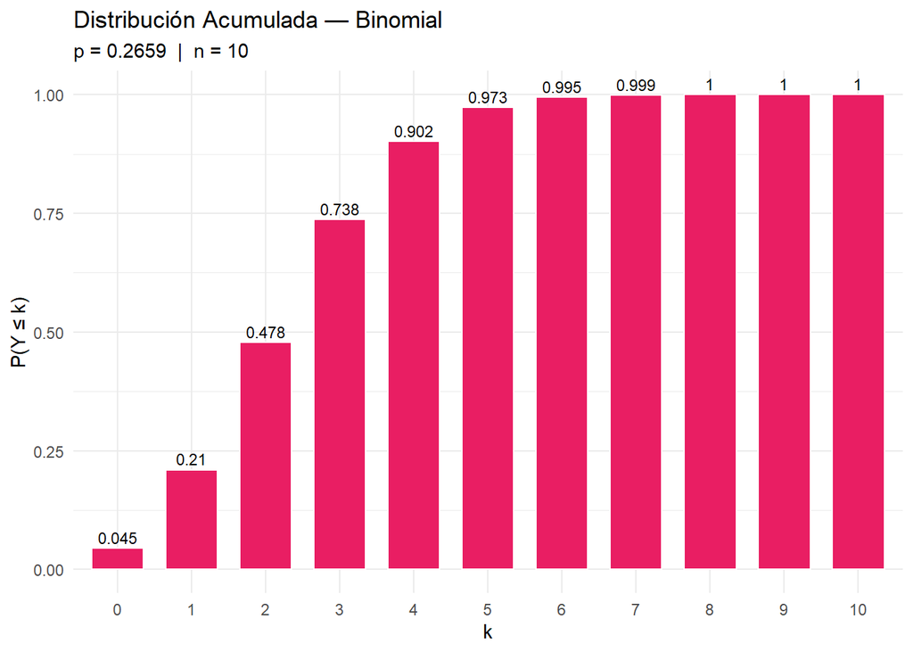

### 6.6.2 Interpretación

De los 1192 estudiantes con datos válidos, el **26.6%** reportó una calidad de sueño **Mala o Muy mala**, por lo que $p = 0.2659$.

Usando $Y \sim \text{Binomial}(10,\ 0.266)$:

- $E(Y) = 2.66$: en un grupo de 10 estudiantes, se esperan en promedio **entre 2 y 3 estudiantes** con calidad de sueño deficiente.
- $SD(Y) = 1.4$: hay variabilidad moderada entre grupos, lo que indica que el resultado puede oscilar entre 1 y 4 estudiantes con frecuencia.
- $P(Y = 2) = 0.2683$: hay un **26.83% de probabilidad** de que exactamente 2 de los 10 estudiantes reporten calidad de sueño Mala o Muy mala.
- $P(Y \leq 3) = 0.7375$: hay un **73.75% de probabilidad** de que a lo mucho 3 de los 10 estudiantes tengan calidad de sueño deficiente.

# 7 Variable Continua 1: Horas de ejercicio semanal

**Variable de estudio:** Horas de actividad física por semana (`HorasEjercicio`) — Cuantitativa continua (0–20 horas)

```r
ejercicio_vec <- DF_seccion$HorasEjercicio
ejercicio_vec <- ejercicio_vec[!is.na(ejercicio_vec)]

mu_ej  <- mean(ejercicio_vec)
sd_ej  <- sd(ejercicio_vec)
lam_ej <- 1 / mu_ej
```

## 7.1 Paso 1: Descriptores estadísticos y validación de distribución

```r
cat("n          :", length(ejercicio_vec), "\n")
```

```
n          : 1186
```

```r
cat("Media      :", round(mu_ej, 4), "horas/semana\n")
```

```
Media      : 3.6793 horas/semana
```

```r
cat("Mediana    :", median(ejercicio_vec), "horas/semana\n")
```

```
Mediana    : 3 horas/semana
```

```r
cat("SD         :", round(sd_ej, 4), "\n")
```

```
SD         : 2.9931
```

```r
cat("Varianza   :", round(sd_ej^2, 4), "\n")
```

```
Varianza   : 8.9585
```

```r
cat("Asimetría  :", round(skewness(ejercicio_vec), 4), "\n")
```

```
Asimetría  : 1.6282
```

```r
cat("Curtosis   :", round(kurtosis(ejercicio_vec), 4), "\n")
```

```
Curtosis   : 6.2409
```

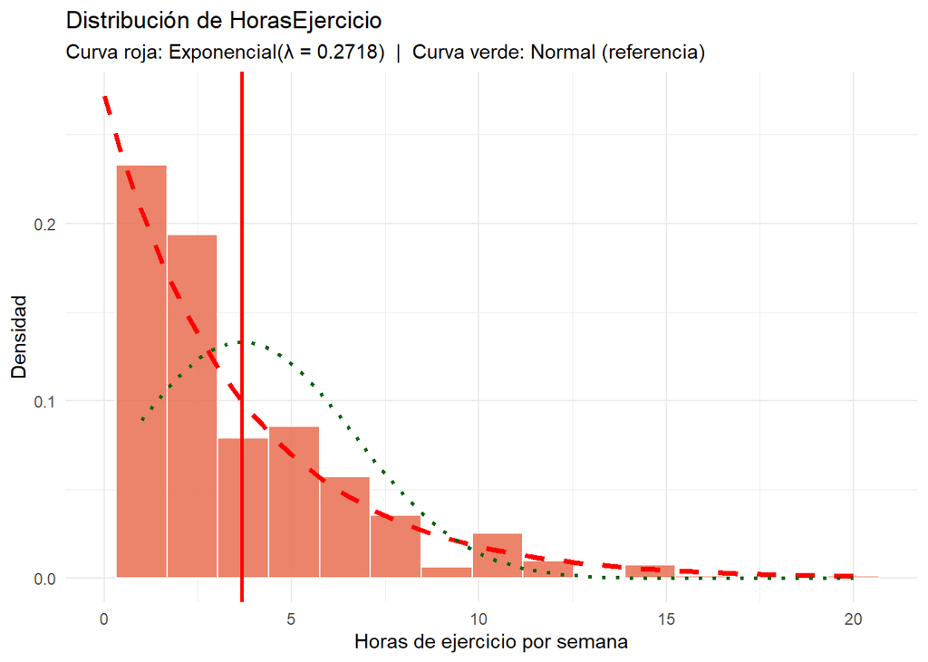

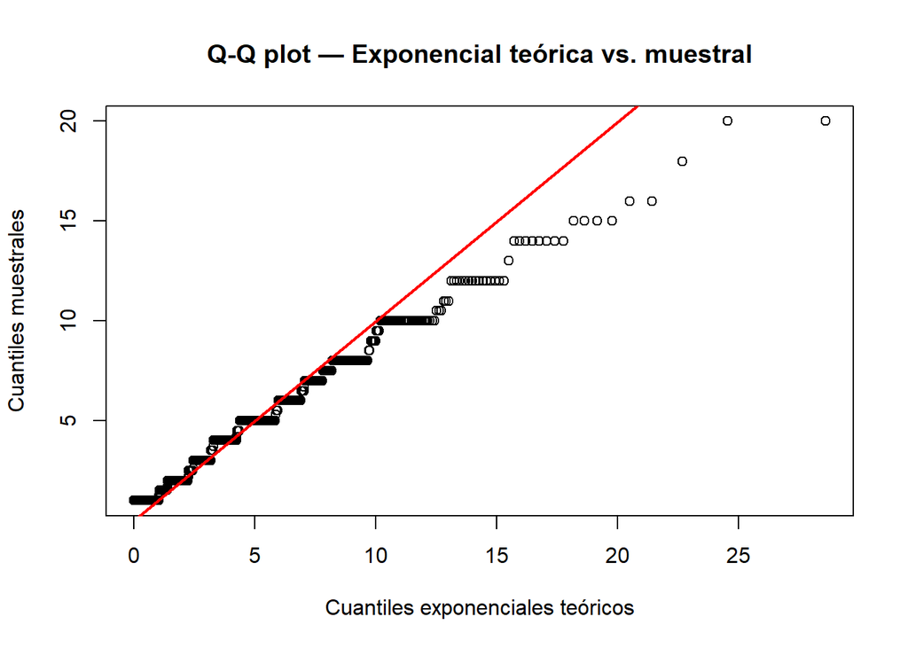

## 7.2 Paso 2: Distribución teórica y propiedades

$$Z \sim \text{Exp}(\lambda)$$

```r
cat("Parámetro:      λ   =", round(lam_ej, 4), "\n")
```

```
Parámetro:      λ   = 0.2718
```

```r
cat("E(Z)  = 1/λ         =", round(1/lam_ej, 4), "horas/semana\n")
```

```
E(Z)  = 1/λ         = 3.6793 horas/semana
```

```r
cat("V(Z)  = 1/λ²        =", round(1/lam_ej^2, 4), "horas²\n")
```

```
V(Z)  = 1/λ²        = 13.5369 horas²
```

```r
cat("SD(Z) = 1/λ         =", round(1/lam_ej, 4), "horas/semana\n")
```

```
SD(Z) = 1/λ         = 3.6793 horas/semana
```

```r
cat("Mediana = ln(2)/λ   =", round(log(2)/lam_ej, 4), "horas/semana\n")
```

```
Mediana = ln(2)/λ   = 2.5503 horas/semana
```

El valor esperado teórico $E(Z) = 3.6793$ horas/semana coincide con la media muestral, respaldando el ajuste. La varianza teórica $V(Z) = 13.5369$ refleja la alta dispersión observada, característica de la exponencial.

## 7.3 Paso 3: Ejemplo — distribución acumulada

Se desea saber cuál es la probabilidad de que un estudiante realice **más de 5 horas** de ejercicio semanal.

$$P(Z > 5) = 1 - P(Z \leq 5) = 1 - F(5)$$

```r
prop_evento <- 1 - pexp(5, rate = lam_ej)
cat("P(Z > 5) =", round(prop_evento, 4), "\n")
```

```
P(Z > 5) = 0.2569
```

```r
cat("Interpretación: el", round(prop_evento * 100, 1),
    "% de los estudiantes realiza más de 5 horas de ejercicio semanal.\n")
```

```
Interpretación: el 25.7 % de los estudiantes realiza más de 5 horas de ejercicio semanal.
```

$P(Z > 5) \approx 0.26$: aproximadamente el **25.7% de los estudiantes** realiza más de 5 horas de ejercicio semanal. Este resultado es coherente con la distribución exponencial ajustada, donde la mayoría se concentra en valores bajos pero existe una probabilidad no despreciable de observar valores altos por la cola derecha.

# 8 Variable Continua 2: Horas de sueño por noche

**Variable de estudio:** Horas de sueño promedio por noche (`HorasSuenio`) — Cuantitativa continua (3–12 horas). Los datos fueron registrados como enteros por el formato de respuesta de la encuesta, pero la variable es continua por naturaleza.

```r
suenio_vec <- DF_seccion$HorasSuenio
suenio_vec <- suenio_vec[!is.na(suenio_vec)]

mu_su <- mean(suenio_vec)
sd_su <- sd(suenio_vec)
```

## 8.1 Paso 1: Descriptores estadísticos y validación de distribución

```r
cat("n          :", length(suenio_vec), "\n")
```

```
n          : 1172
```

```r
cat("Media      :", round(mu_su, 4), "horas/noche\n")
```

```
Media      : 6.3444 horas/noche
```

```r
cat("Mediana    :", median(suenio_vec), "horas/noche\n")
```

```
Mediana    : 6 horas/noche
```

```r
cat("SD         :", round(sd_su, 4), "\n")
```

```
SD         : 1.3698
```

```r
cat("Varianza   :", round(sd_su^2, 4), "\n")
```

```
Varianza   : 1.8764
```

```r
cat("Asimetría  :", round(skewness(suenio_vec), 4), "\n")
```

```
Asimetría  : 0.2641
```

```r
cat("Curtosis   :", round(kurtosis(suenio_vec), 4), "\n")
```

```
Curtosis   : 3.5724
```

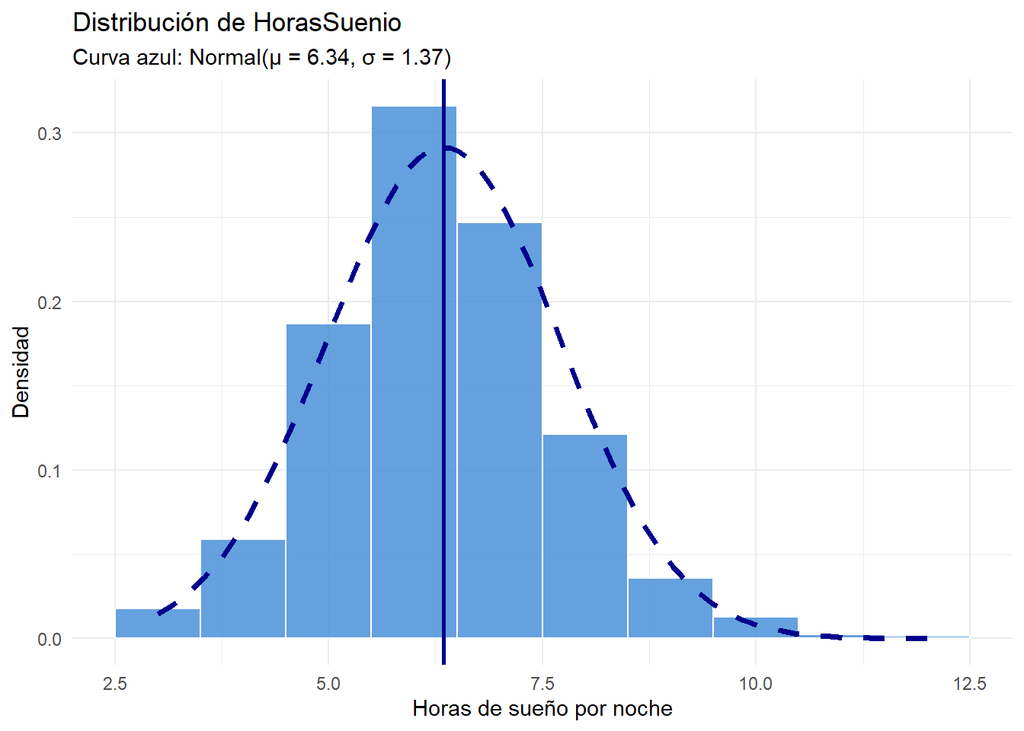

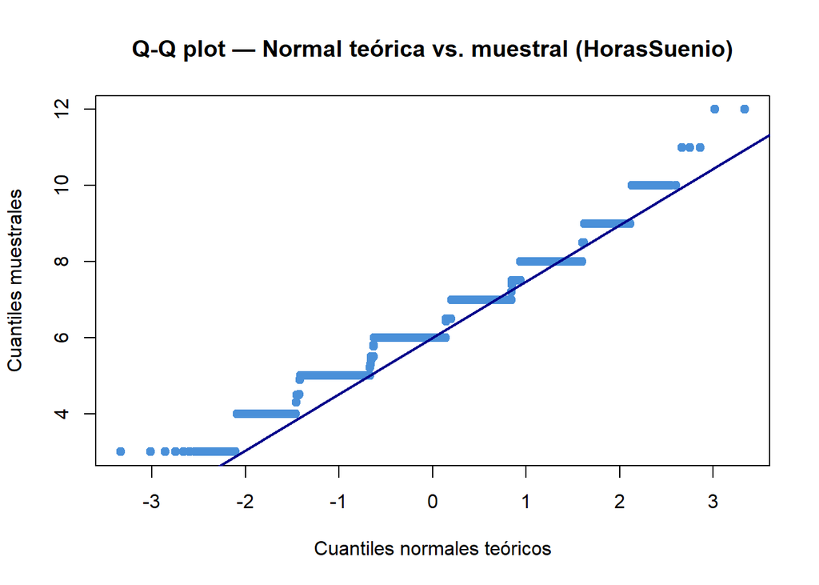

La variable **HorasSuenio** presenta una distribución **aproximadamente normal**: la asimetría de **0.26** es cercana a cero y la curtosis de **3.57** se acerca al valor de referencia de 3, lo que indica una distribución levemente leptocúrtica pero compatible con la normal. El histograma muestra una forma de campana centrada alrededor de las 6–7 horas con la curva teórica ajustando bien la zona central. El Q-Q plot muestra buen ajuste en el rango de 4 a 9 horas; la desviación notable en los valores extremos superiores (10–12 horas) refleja que un grupo reducido de estudiantes duerme más de lo que la distribución normal predice, lo que es esperable en una muestra real. El patrón escalonado del Q-Q se debe al registro de respuestas como enteros. En conjunto, la **distribución Normal es una aproximación razonable** para modelar esta variable.

## 8.2 Paso 2: Distribución teórica y propiedades

$$W \sim \text{Normal}(\mu,\ \sigma)$$

```r
cat("Parámetros:\n")
```

```
Parámetros:
```

```r
cat("  μ (media)        =", round(mu_su, 4), "horas/noche\n")
```

```
  μ (media)        = 6.3444 horas/noche
```

```r
cat("  σ (desv. est.)   =", round(sd_su, 4), "\n")
```

```
  σ (desv. est.)   = 1.3698
```

```r
cat("E(W)  = μ          =", round(mu_su,    4), "horas/noche\n")
```

```
E(W)  = μ          = 6.3444 horas/noche
```

```r
cat("V(W)  = σ²         =", round(sd_su^2,  4), "horas²\n")
```

```
V(W)  = σ²         = 1.8764 horas²
```

```r
cat("SD(W) = σ          =", round(sd_su,    4), "\n")
```

```
SD(W) = σ          = 1.3698
```

```r
cat("Mediana = μ        =", round(mu_su,    4), "horas/noche\n")
```

```
Mediana = μ        = 6.3444 horas/noche
```

La distribución Normal es **simétrica**, por lo que media, mediana y moda coinciden en $\mu = 6.34$ horas. La desviación estándar $\sigma = 1.37$ indica que la mayoría de estudiantes duerme entre 5 y 7.7 horas por noche.

## 8.3 Paso 3: Ejemplo — distribución acumulada

Se desea saber cuál es la probabilidad de que un estudiante duerma entre **6 y 8 horas** por noche (rango recomendado para universitarios).

$$P(6 \leq W \leq 8) = F(8) - F(6)$$

```r
P_rango <- pnorm(8, mean = mu_su, sd = sd_su) - pnorm(6, mean = mu_su, sd = sd_su)

cat("P(6 ≤ W ≤ 8) =", round(P_rango, 4), "\n")
```

```
P(6 ≤ W ≤ 8) = 0.4859
```

```r
cat("Interpretación: el", round(P_rango * 100, 1),
    "% de los estudiantes duerme entre 6 y 8 horas por noche.\n")
```

```
Interpretación: el 48.6 % de los estudiantes duerme entre 6 y 8 horas por noche.
```